# SQL, keys, indexes, and B+ trees

● SQL database essentials

# SQL, keys, indexes & *B+ trees*

What is SQL? What are its primary features? How does it Index? How does a tree structures power billions of queries per second.

SQL foundations Keys & Constraints Index Structures B+ Tree Internals

Scroll to explore↓

01

Foundations

## What is SQL & how do tables work?

SQL is the language of relational databases. Instead of storing everything in one spreadsheet or file, SQL stores related pieces of information in separate tables. Queries combine those tables only when needed.

students table

| student_id | name | major | year |
| --- | --- | --- | --- |
| 1001 | Alex | CS | Sophomore |
| 1002 | Maria | Math | Junior |
| 1003 | Sam | CS | Sophomore |
| 1004 | Nina | Physics | Senior |

SELECT name, major  
FROM students  
WHERE year = 'Sophomore';

students

PKstudent_id

name

major

year

student_id ↔ links

enrollments

PKenroll_id

FKstudent_id

course_id

grade

| enroll_id | student_id | course_id |
| --- | --- | --- |
| E001 | 1001 | CS301 |
| E002 | 1001 | CS401 |
| E003 | 1003 | CS301 |

Defining keys in SQL

CREATE TABLE students (  
student_id INT PRIMARY KEY,  
name VARCHAR(100),  
major VARCHAR(100)  
);  
CREATE TABLE enrollments (  
enrollment_id INT PRIMARY KEY,  
student_id INT,  
course_id INT,  
FOREIGN KEY (student_id)  
REFERENCES students(student_id)  
);  
-- Add a primary key after creation:  
ALTER TABLE students  
ADD PRIMARY KEY (student_id);  
-- Add a foreign key after creation:  
ALTER TABLE enrollments  
ADD CONSTRAINT fk_student  
FOREIGN KEY (student_id)  
REFERENCES students(student_id);

PRIMARY KEY

Defined at table creation *or* added later with `ALTER TABLE`

FOREIGN KEY

Defined at table creation or added later with `ADD CONSTRAINT`

1.1 · SQL Foundations

### SQL is declarative and remote

**SQL** (Structured Query Language) lets you create, query, update, and manage relational databases. A relational database stores data in *tables* — rows are records, columns are attributes/variables.

The key insight: SQL is **declarative**. You specify what data you want; the database engine's optimizer figures out how to retrieve it efficiently. This is why the same SQL query can run substantially faster with an index than without.

SQL queries are sent to a server (SQL server) where the database is stored, though this server is often remote, that doesn't have to be the case. SQL handles everything in executing the query and returns the resulting data to the user.

On the left is an example of a SQL query on the table *students* that retreives the name and major of Sophmore students in the table.

Declarative Relational Structured Query Language

1.2 · Tables & relationships

### Relational aspect of SQL and Keys

A **table** represents an entity — students, courses, orders. Each row is one record; each column is one attribute. A **primary key** uniquely identifies each row.

A **primary key** must be unique and never NULL. Most tables have one primary key, though composite keys (multiple columns) are valid and identify rows through a composition of multiple columns.

Relational databases become powerful when multiple tables are *connected*. To do this: A **foreign key** is a column that references another table's primary key. A foreign key doesn't have to be made up of unique values but it does need to reference a primary key (which is made up of unique values). It enforces *referential integrity* — you cannot enroll a student who doesn't exist. The database prevents the inconsistency at the constraint level.

The `student_id` column bridges the **students** and **enrollments** tables which enables powerful joins without redundancy. A foreign key defines and enforces a relationship between tables.

Entities Attributes No Duplication Joins

1.3 · Primary & foreign keys

### How to create keys in context

On the left is the SQL command for creating primary and foreign keys in a SQL database.

The `CREATE TABLE` command is used when one creates the key at the same time as creating the SQL table itself.

The `ALTER TABLE` command is used when the table was already created but has no pre-defined key. For a **primary key** within the query one would use `ADD PRIMARY KEY` and for a **foreign key** within the query one would use `ADD CONSTRAINT` and must specify the constraint is a foreign key and the primary key that the foreign key references.

Common confusion: a foreign key is simply *a column in your table*. The relationship is established from by declaring it as a reference to another table's primary key with a `FOREIGN KEY` constraint.

Unique Not NULL Referential Integrity Composite Keys

Key insight

Keys define relationships. Indexes make those relationships fast to query.

A primary key is a logical constraint (a column). An index is the underlying data structure the database mainatains to turn a key lookup from O(n) into O(log n). They coexist but are fundamentally different things.

02

Performance Structures

## Indexes

An index is a separate ordered data structure that helps the database find rows faster by storing indexed column values and references to the corresponding table rows.

Physical rows vs. Index order

Physical table

Row 1 Tom

Row 2 Alex

Row 4 Nina

Row 7 Maria

Row 9 Sam

→

Index on name

Alex → Row 2

Maria → Row 7

Nina → Row 4

Sam → Row 9

Tom → Row 1

CREATE INDEX idx_name  
ON students(name);  
CREATE INDEX idx_enroll_student  
ON enrollments(student_id);

❌ Full table scan (no index)

Every row checked. Complexity: O(n).

✅ Index lookup

Root

→

Branch

→

Leaf

→

Match!

O(n)

Full scan

O(log n)

Index lookup

Index tradeoffs

#### ✅ Reads

- Faster WHERE
- Faster JOINs
- Efficient ORDER BY
- Fast range queries

#### ⚠️ Writes

- Slower INSERT
- Slower UPDATE
- Slower DELETE
- Extra storage

Selectivity matters

email = 'x@example.com'High ✓

Matches ~1 row of millions

status = 'active'Low ✗

Matches 60% of rows — index barely helps

country = 'US'Medium

Depends on data distribution

2.1 · What is an Index

### An index is a sorted, separate access structure

An **index** is a separate data structure — like a phonebook or a textbook's back index — that helps the database find rows without reading every single one.

The physical rows in a table can be in any order. An index stores keys in *sorted logical order* with references (row pointers) to where those rows actually live. The table itself doesn't move.

Important: a **key** is a logical constraint (unique, not null). An **index** is a physical performance structure. Primary keys usually get an index automatically in MySQL/InnoDB — but the concepts are distinct.

Sorted Keys Row References Separate Structure Faster Lookup

2.2 · Why Indexes Help

### Advantage: Prevents scanning every row, by following a guided path

Without an index on email, finding `WHERE email = 'x@example.com'` requires inspecting every row — a *full table scan*. With millions of rows this leads to computing inefficiencies and prolonged runtimes.

With an index, the database follows an ordered tree path — root → branch → leaf — touching only a handful of nodes to land on the match. Essentially, an index cuts down the total number of comparisons needed to identify a row. This is the difference between O(n), which is the runtime without an index, and O(log n) which is the decreased runtime through an index.

Indexes are most impactful for `WHERE` filters, `JOIN` conditions, `ORDER BY` sorting, and range queries like `BETWEEN`. Below the structure and functionality of an index is explained in depth.

WHERE clauses JOIN conditions ORDER BY Range queries

2.3 · Limitations & Tradeoffs

### Indexes are not always fast and beneficial

Indexes speed up reads but slow down writes. Every `INSERT`, `UPDATE`, or `DELETE` must also update every relevant index which causes the structure of the index to alter. Too many indexes increase maintenance cost and storage of the database.

**Selectivity** is critical. An index on a column with few distinct values (like a boolean `is_active` or `status`) may not help — too many rows match, and the database may choose a full scan anyway since that may be more efficient.

Although primary keys must be unique by definition, a regular index (created with CREATE INDEX) has no uniqueness requirement at all. Sometimes, regular indexes can be helpful to speed up row retrieval and querying even if they aren't for primary keys. It is still important to consider selectivity or uniqueness when creating a regular index, as an index on a column with low selectivity may not provide performance benefits and can even degrade performance due to the overhead of maintaining the index and the potential for increased table lookups.

Even with a perfect index, a query can still be slow if it matches many rows (leaf scanning) or those rows are scattered across many storage pages and has to perform many table lookups. Table lookups happen when the database engine jumps from the index back to the main table to retrieve a full row of data after finding a match in the index. This is not a problem in MySQL because the table data lives directly in the primary key's B+ tree leaves (clustered index), so there's no second trip. Secondary indexes, however, (on non-primary-key columns) always require a second lookup back to the primary key tree to get the full row.

Write overhead Low selectivity Leaf scanning Table lookups

So what structure does an index use?

Most database indexes are B trees. MySQL uses B+ trees which are a balanced tree structure designed for disk-based storage with high fanout and sorted leaf chains.

Understanding the tree explains why indexes are fast for both equality lookups and range queries, and why they stay efficient even with millions of rows.

03

Data Structures

## B+ trees

The tree structure that makes indexes fast and optimized in MySQL.

B+ Tree Structure

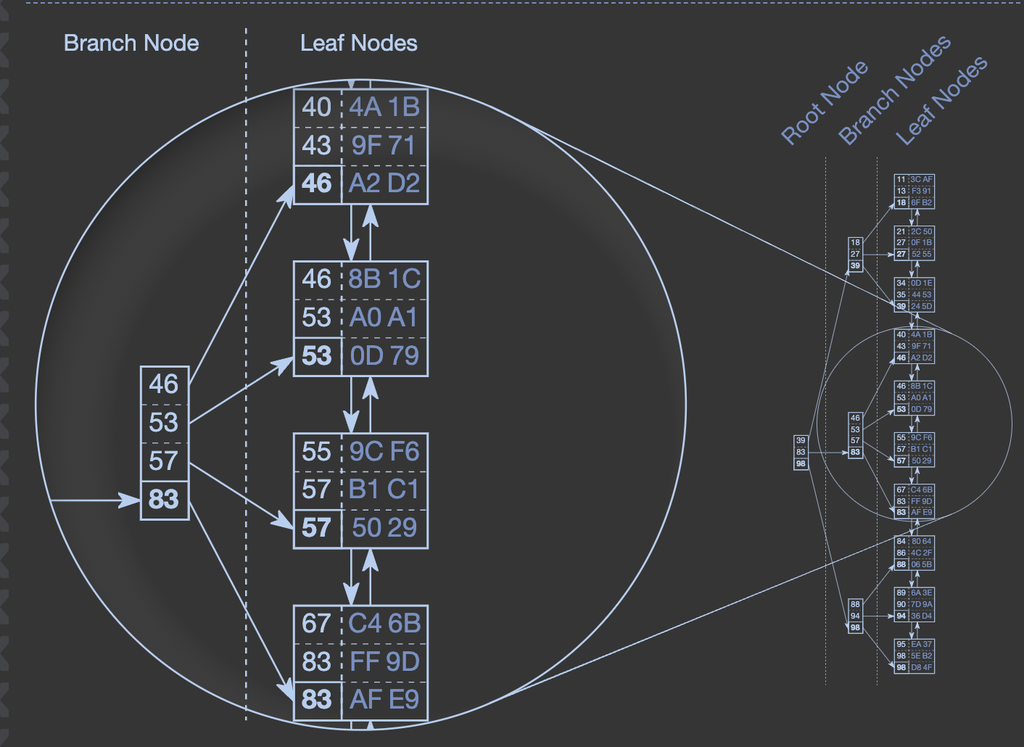

Search path for key 57

[figure not shown]

1

**Root** [39|83|98]: 57 > 39 and < 83 → middle pointer

2

**Branch** [46|53|57|83]: 57 = 57 → leaf pointer

3

**Leaf** [55|57|57]: key found, return row reference

Why B+ trees stay shallow

Fanout of 100 → 3 levels covers

1,000,000

leaf entries with only 3 page reads

ROOT

↓ × many pointers

Br

Br

Br

...

↓ × many pointers

Lf

Lf

Lf

Lf

...

Equality

Root → leaf in O(log n)

Range

Walk sorted leaf chain

3.1 · B+ Tree Structure

### Root, branches, leaves

A **B+ tree** has three node types. The *root* at the top is the entry point for every search. *Branch nodes* in the middle store only keys and pointers — they guide the search but hold no row data. *Leaf nodes* at the bottom store the actual index entries and row references.

In MySQL/InnoDB, the primary key index is **clustered** — the actual table row data lives in the leaf nodes of the primary key B+ tree. Secondary indexes store the indexed column value plus the corresponding primary key, requiring a second tree lookup to retrieve the full row.

Root node Branch nodes Leaf nodes Clustered index

3.2 · Leaf Chain

### Leaf nodes are linked for range scans

To answer `WHERE score BETWEEN 43 AND 67`, the database traverses the tree to find 43, then simply walks the leaf chain to collect everything up to 67 — no re-traversal needed.

Sorted chain Range scans BETWEEN ORDER BY

3.3 · Tree Traversal

### Tree traversal walk-through

Consider the task where the goal is to search for a key **57**: start at the root `[39|83|98]`. Since 57 is between 39 and 83, follow the middle pointer. At branch `[46|53|57|83]`, find the position of 57 and follow to the leaf `[55|57|57]`. Found.

Notice that only **one node is visited per level**. This is always true for any key lookup in a B+ tree, regardless of the key or the size of the data. At each node, the search key is compared against the stored keys and exactly one pointer is followed downward. The result is that the number of nodes inspected is always exactly equal to the depth of the tree. This is where the O(log n) runtime comes from: each level cuts the search space by the branching factor, and the tree's depth grows only logarithmically with the number of rows.

O(log n) One path Exact lookup

3.4 · Efficiency & Fanout

### Shallow trees handle millions of rows in 3–4 reads

Each node in a B+ tree corresponds to one **page** (typically 16 KB in MySQL/InnoDB). Because a page can hold hundreds of keys, the *fanout* — the number of entries per node — is very high.

With fanout 100: level 1 (root) covers 100 branches. Level 2 covers 10,000. Level 3 covers 1,000,000 leaves. Therefore, a tree covering a million rows reads only 3 pages for any lookup. That's why B+ trees scale so well.

The tree is always **balanced** — all leaf nodes sit at the same depth — because insertions and deletions trigger automatic node splits and merges that propagate up the tree to maintain this property. This guarantees predictable search time regardless of which key you look up.

Efficient Always balanced Predictable

3.4 · Efficiency & Fanout

### Index structures differ across SQL dialects

MySQL primarily uses B+ trees to structure its indexes, but other dialects treat indexing slightly differently. For example, PostgreSQL and SQLite default to B tree indexing, where (among other differences) row data is stored in all levels of the tree rather than just in the leaves. In Postgres, it is also possible to manually choose alternative indexing strategies like hash (simple and efficient for equality comparisons) or GiST operating classes (for geometric data and nearest-neighbor queries). Generally, though, understanding the structure of B and B+ trees is essential to creating and working with indexes in SQL.

B vs. B+ trees Manual index structure selection

04

Best Practices

## Practical indexing: What to take away from indexing

Knowing the theory behind indexes can be helpful but only if you know how to utilize the information for your own good.

Composite index: (customer_id, order_date)

Sorted by customer_id first, then order_date within each customer:

cust: 1

2024-01-05

cust: 1

2024-03-12

cust: 1

2024-07-01

cust: 2

2024-02-18

cust: 2

2024-09-30

· · ·

cust: 10

2024-01-09 ← found

CREATE INDEX idx_cust_date  
ON orders(customer_id, order_date);  
EXPLAIN  
SELECT * FROM orders  
WHERE customer_id = 10  
ORDER BY order_date;

SQL indexes: OLTP vs. OLAP

✅ OLTP

Transactional

Finds few specific rows

B+ tree skips most data

Joins on foreign keys

WHERE, lookup, update

O(log n) and index beneficial

⚠️ OLAP

Analytical

Scans many/all rows

Index can't help a full scan

Aggregates whole columns

AVG, SUM, GROUP BY

O(n) and index not beneficial

**Use SQL + B+ tree indexes** for transactional row lookups.  
**Use DuckDB / Snowflake** for analytical column scans.

4.1 · Composite Indexes

### Column order (during creation) in composite indexes is critical

A composite index on `(customer_id, order_date)` sorts first by `customer_id`, then by `order_date` within each customer group. This makes queries that filter by `customer_id` alone very efficient.

It also helps queries filtering by both columns, and sorting by `order_date` after filtering by `customer_id`. However, a query filtering only by `order_date` won't benefit much — the index isn't sorted by that column alone.

What to take away: **put the column you filter on most frequently first** when creating a composite index. Doing so improves both lookup speed and query efficiency compared to any other column ordering.

Leading column first Prefix matching Column order matters

4.2 · Guidelines

### Indexes make SQL fast for row-based, transactional queries

SQL indexes are purpose-built for **OLTP** — Online Transactional Processing. These are queries that locate and return a small number of specific rows: find one customer, update one order, look up one student. The B+ tree traverses from root to leaf in O(log n) and lands on exactly the rows you need, touching almost nothing else in the table.

This is fundamentally different from **analytical queries** — the kind that ask "what is the average grade across all students?" or "how many orders were placed per month this year?" Those queries need to scan many or all rows and aggregate across entire columns. An index does not help here because there is no shortcut — every row must be read regardless. This workload is called **OLAP** (Online Analytical Processing).

SQL finds the right rows fast through its indexes, but analytical queries need to read one column across millions of rows meaning the database still has to touch every row's storage page. This makes analytical queries less efficient in SQL compared to transactional queries (row-based). However, based on the index model of SQL, SQL is especially efficient and strong for row-based queries.

The practical takeaway: **use SQL and its B+ tree indexes for transactional workloads** like precise lookups, joins on foreign keys, filtering by specific values. For large-scale analytical work across many rows and few columns, a column-oriented system is the better architectural choice (like DuckDB or Snowflake).

OLTP Row lookup OLAP Column scan

## Key Takeaways

01

**SQL** is a declarative language, a query is sent to a remote SQL server, and the optimizer decides how to retrieve it efficiently. Rows are records, columns are attributes.

02

**Primary keys** uniquely identify rows and must be unique and never NULL. **Foreign keys** are columns that reference another table's primary key. They create relationships and enforce referential integrity. Both can be defined at table creation or added later with **ALTER TABLE**.

03

**Indexes** are separate physical structures, distinct from keys, that store column values in sorted order with row references. They reduce lookups from O(n) full scans to O(log n) guided tree traversal. Composite indexes require putting the most-filtered column first for maximum efficiency.

04

**B+ trees** power MySQL indexes. The root is the entry point, branch nodes guide the search, and leaf nodes store the data. Leaf nodes are linked in sorted order enabling fast range scans. With high fanout, just 3–4 levels can cover millions of rows.

05

Indexes **speed up reads but slow down writes** — every INSERT, UPDATE, and DELETE must also update the index structure. Low-selectivity columns (like booleans or status fields) benefit little from indexing since too many rows match.

06

SQL indexes excel at **OLTP**, precise row lookups, joins on foreign keys, transactional queries. For **OLAP** analytical workloads that scan entire columns across millions of rows, column-oriented systems like DuckDB or Snowflake are the better architectural choice.